# Lecture 6: Introduction to statistics and descriptive statistics

Mathematics and Statistics BS1515

Theodoros Arvanitopoulos

2025-11-20

# Learning objectives

### Introduction to statistics

- Understand what statistics is and why it is useful.
- To be able to distinguish between different types of variables and data.
- To understand the use of diagrams/graphs and to how to draw conclusions.

### Numerical data

- To understand measures of central tendency, location, and variation in the data.
- To understand the advantages and disadvantages of different measures.
- To understand which measures to use and how to interpret them.

### 📚 Reading

Newbold et al. (2020), *Statistics for Business and Economics*, Ch. 1–2.

# What is statistics?

Statistics is the science of collecting, organizing, presenting, analysing, and interpreting data to assist in making more effective decisions.

Economists use statistics to test assumptions and inform policy making.

*Example*: The BoE uses data on inflation and employment to inform decision on interest rates.

Two branches of statistics:

**Descriptive statistics**

Graphical and numerical procedures to summarize and process data.

**Inferential statistics**:

Using data to make predictions, forecasts, and estimates to assist decision making (estimation and hypothesis testing)

# Key statistical concepts

**Population (**$N$) is the complete group under study.

- $N$ represents the population size
- values calculated using population data are called **parameters**
- *example*: census or population of a country.

**Sample (**$n$) is an observed subset of the population.

- n represents the sample size
- values computed from sample data are called **statistics**
- *example*: 2 millions from the population

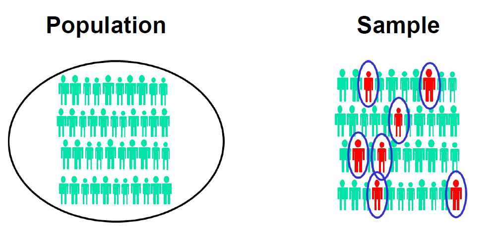

# Sampling methods

**Simple random sampling** → **random sample**

- select randomly a sample of $n$ objects from a population
- each member of the population is equally likely to be chosen
- selection of one doesn’t affect the selection of any other member

**Systematic sampling** → **systematic sample**

- population is arranged so that is not related to the subject of interest
- select randomly an item every $j= N/n$ of the population

**Inference** is the process of drawing conclusions or making decisions about a population based on sample results.

# Types of data

A **variable** has two characteristics:

1. it is an attribute/characteristic that describes a person, place, thing, or idea
2. its value can “*vary*” from one entity to another

# Types of data

A **variable** has two characteristics:

1. it is an attribute/characteristic that describes a person, place, thing, or idea
2. its value can “*vary*” from one entity to another

Types of variables:

**Quantitative/Numerical** variables take numerical values (e.g. the number of children per family).

- *discrete*: (positive) integer values (e.g., number of children per household)
- *continuous*: any real numerical values (e.g., weight)

**Qualitative/Categorical** variables take non numerical values (e.g., the colour of a ball).

- *nominal*: non-measurable categories (e.g. colours: red, blue, yellow, etc)
- *ordinal*: categories with meaningful order (e.g. education level: high school, bachelor’s, master’s, PhD)

# Types of data

A **variable** has two characteristics:

1. it is an attribute/characteristic that describes a person, place, thing, or idea
2. its value can “*vary*” from one entity to another

Types of variables:

- *discrete*: (positive) integer values (e.g., number of children per household)
- *continuous*: any real numerical values (e.g., weight)

- *nominal*: non-measurable categories (e.g. colours: red, blue, yellow, etc)
- *ordinal*: categories with meaningful order (e.g. education level: high school, bachelor’s, master’s, PhD)

| Data Type | Subtype | Description | Example |
| --- | --- | --- | --- |
| Categorical | Nominal | No order | Gender, Blood Type |
|  | Ordinal | Ordered categories | Education Level |
| Numerical | Discrete | Countable | Number of Children |
|  | Continuous | Measurable | Weight, Temperature |

# Visualizing categorical data

### Bar chart (NHS Wales data)

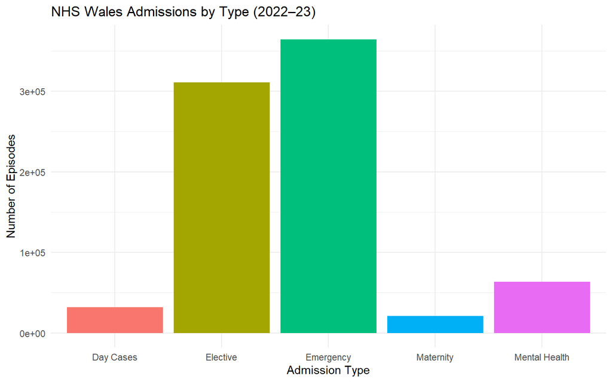

# Visualizing categorical data

### Pie charts (NHS Wales data)

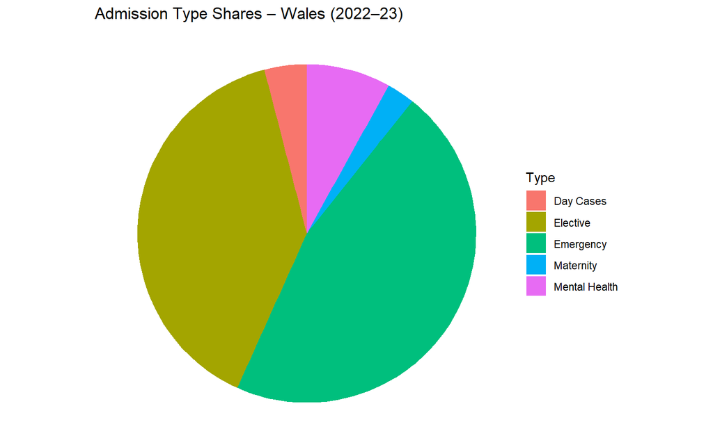

# Visualizing numerical data

### Line plot (financial data)

Comparing the **natural logarithm of daily closing prices** for the **FTSE 100** and **S&P 500** since 2016.

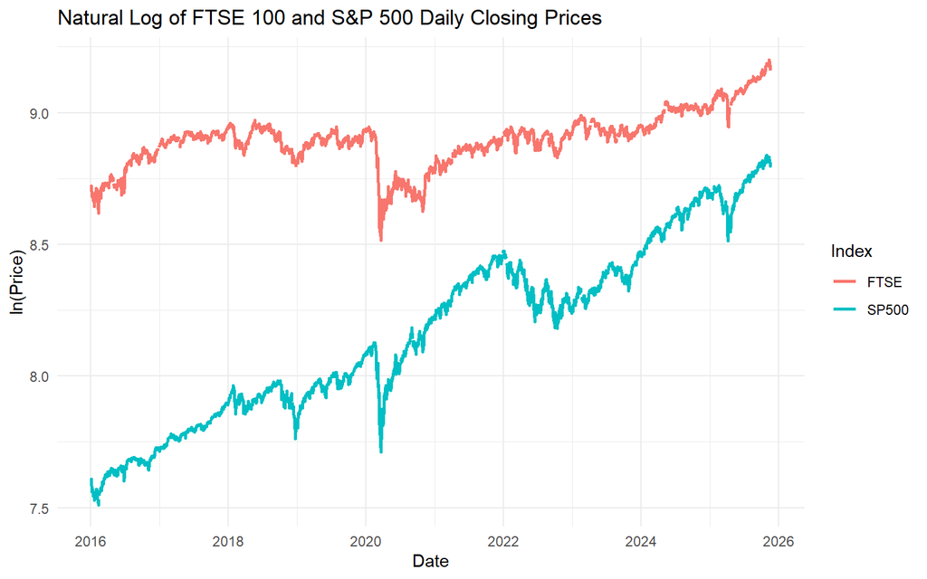

*Note*: We often use a **log scale** to compare assets with different price levels, making relative growth more interpretable. Taking the natural log helps stabilise variance and compare relative returns.

# Measures of Central Tendency

1. **Mean**: Arithmetic average
2. **Median**: Midpoint of ranked values
3. **Mode**: Most frequently observed value (if one exists)

# Measures of Central Tendency

1. **Mean**: Arithmetic average
2. **Median**: Midpoint of ranked values
3. **Mode**: Most frequently observed value (if one exists)

*Example*: consider the following random sample and its measures of central tendency.

```r
# Using R to find measures of central tendency
x <- c(24, 35, 17, 21, 24, 37, 26, 46, 58, 30, 32, 13, 12, 38, 41, 43, 44, 27, 53, 27)
mean(x)
```

```
## [1] 32.4
```

```r
median(x)
```

```
## [1] 31
```

```r
Mode <- function(v) {
  uniqv <- unique(v)
  uniqv[which.max(tabulate(match(v, uniqv)))]
}
Mode(x)
```

```
## [1] 24
```

# Mean (arithmetic average)

The arithmetic mean (mean) is the most common measure of central tendency.

The mean is the sum of values divided by the number of values.

For a **population** of $N$ values:

$$\mu = \frac{1}{N} \sum_{i=1}^{N} x_i = \frac{x_1+x_2+...+x_N} {N}$$

where $x$ are the population values and $N$ the population size.

# Mean (arithmetic average)

The arithmetic mean (mean) is the most common measure of central tendency.

The mean is the sum of values divided by the number of values.

For a **population** of $N$ values:

$$\mu = \frac{1}{N} \sum_{i=1}^{N} x_i = \frac{x_1+x_2+...+x_N} {N}$$

where $x$ are the population values and $N$ the population size.

For a **sample** of size $n$:

$$\bar{x} = \frac{1}{n} \sum_{i=1}^{n} x_i = \frac{x_1+x_2+...+x_n} {n}$$

where $x$ are the observed values and $n$ is the sample size.

# Mean - Example using R

```r
# Example using R
values1 <- c(1, 2, 3, 4, 5)
mean(values1)  # mean = 3
```

```
## [1] 3
```

```r
values2 <- c(1, 2, 3, 4, 10)
mean(values2)  # mean = 4
```

```
## [1] 4
```

So, $\frac{1+2+3+4+5}{5}=\frac{15}{5}=3$ and $\frac{1+2+3+4+10}{5}=\frac{20}{5}=4$

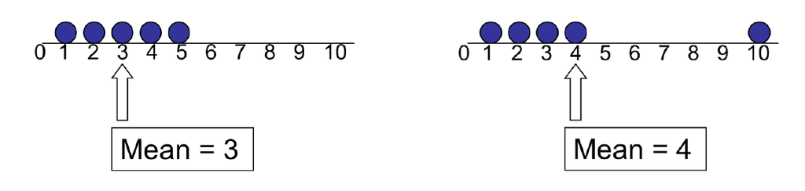

**Note:** The mean is sensitive to outliers.

# Median

The **median** is the “middle” value of an ordered dataset (50% above, 50% below).

- If the number of values is odd, the median is the middle number
- If the number of values is even, the median is the average of the two middle numbers

The location of the median:

$$Median \ \ position \ \ = (\frac{n+1}{2})^{th} \ \ position \ \ in \ \
the \ \ ordered \ \ data$$
Note that $\frac{n+1}{2}$ is not the value of the median, only the position of the median in the ranked data.

# Median - Example using R

```r
# Median Example using R
median(values1)  # median = 3
```

```
## [1] 3
```

```r
median(values2)  # median = 3
```

```
## [1] 3
```

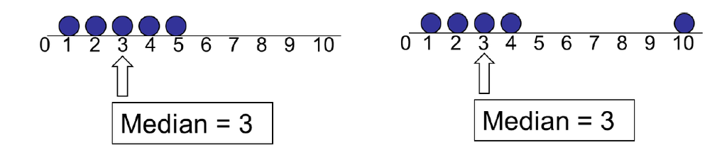

*Note*: The **median is not affected by extreme values**, making it more robust than the mean in skewed data.

# Mode

The **mode** is the most frequently occurring value in a dataset.

The mode is not affected by extreme values and can be used for either numerical or categorical data.

However, if all numbers in the sample have the same frequency of occurrence, then there is no mode.

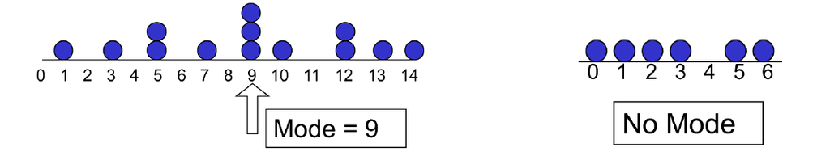

# Mode

The **mode** is the most frequently occurring value in a dataset.

The mode is not affected by extreme values and can be used for either numerical or categorical data.

However, if all numbers in the sample have the same frequency of occurrence, then there is no mode.

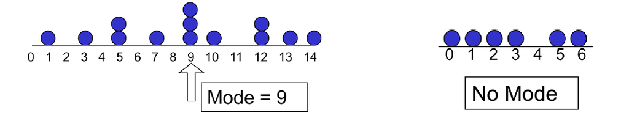

### Example using R

```r
# Mode function using R
Mode <- function(v) {
  uniqv <- unique(v)
  uniqv[which.max(tabulate(match(v, uniqv)))]
}

values3 <- c(0, 1, 2, 3, 4, 5, 6, 7, 8, 9, 10, 11, 12, 13, 14, 9)
Mode(values3)  # mode = 9
```

```
## [1] 9
```

```r
values4 <- c(0, 1, 2, 3, 4, 5, 6)
Mode(values4)  # no mode (all unique)
```

```
## [1] 0
```

# Which measure is best?

### Mean

- It is generally used unless extreme values (outliers) exist.
- Most common starting point for analysing descriptive statistics for datasets.

### Median

- It is often used when there are extreme values (outliers) or data skewed.
- e.g. You often see discussions about median income in the UK, and not mean income.

### Mode

- It is often preferred when when dealing with categorical data or when the most frequent item is relevant.

# Skewness - Shape of Distribution

The shape of a distribution describes how data are distributed and it’s a measure of shape.

**Left-skewed**: Mean < Median

**Symmetric**: Mean ≈ Median

**Right-skewed**: Mean > Median

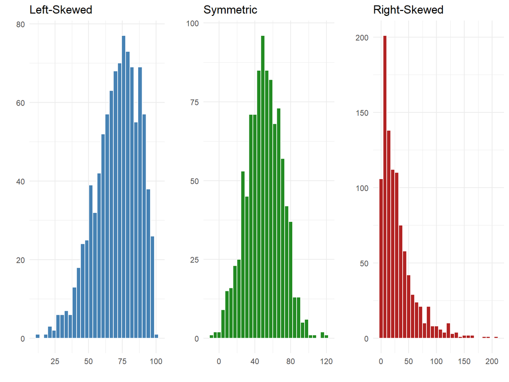

# Geometric mean

Geometric mean is used to measure the rate of change of a variable over time

$$\bar{x}_g=\sqrt[n]{x_1x_2... x_n}=(x_1x_2... x_n)^{1/n}$$
The geometric mean rate of return measures the status of an investment over time

$$\bar{r}_g=(x_1x_2... x_n)^{1/n}-1$$

where $x_i$ is the rate of return in the time period $i$

# Geometric mean

Geometric mean is used to measure the rate of change of a variable over time

$$\bar{x}_g=\sqrt[n]{x_1x_2... x_n}=(x_1x_2... x_n)^{1/n}$$
The geometric mean rate of return measures the status of an investment over time

$$\bar{r}_g=(x_1x_2... x_n)^{1/n}-1$$

where $x_i$ is the rare of return in the time period $i$

### Example

An investment of $100,000 rose to $150,000 at the end of year one and increased to $180,000 at end of year two.

**Misleading results**: Using the arithmetic mean rate of return → $\bar{X} = \frac{(50\%)+(20\%)}{2}=35%$

# Percentiles and quartiles

Percentiles and quartiles indicate the position of a value relative to the entire set of data

- Generally used to describe large data sets
- Example: An IQ score at the $90^{th}$ percentile means that $10\%$ of the population has a higher IQ score and $90\%$ have a lower IQ score.

$P^{th}$ percentile= value located in the $(P/100)(n+1)^{th}$ ordered position

# Percentiles and quartiles

Percentiles and quartiles indicate the position of a value relative to the entire set of data

- Generally used to describe large data sets
- Example: An IQ score at the $90^{th}$ percentile means that $10\%$ of the population has a higher IQ score and $90\%$ have a lower IQ score.

$P^{th}$ percentile= value located in the $(P/100)(n+1)^{th}$ ordered position

### Quartiles

Quartiles split the ranked data into 4 segments with an equal number of values per segment (note that the widths of the segments may be different)

Find a quartile by determining the value in the appropriate position in the ranked data, where

- $1^{st}$ quartile position: $Q_1=0.25(n+1)$ ; $Q_1$ is the value for which 25% of the observations are smaller and 75% are larger
- $2^{nd}$ quartile position: $Q_1=0.50(n+1)$ ; $Q_2$ is the same as the median (50% are smaller, 50% are larger)
- $3^{rd}$ quartile position: $Q_2=0.75(n+1)$ ; only 25% of the observations are greater than $Q_3$

# Quartile example using R

Find the first quartile of the following sample ranked data:

```r
# Define the sample data (unsorted)
sample_data <- c(11, 12, 13, 16, 16, 17, 18, 21, 22)

# Sort the data
sorted_data <- sort(sample_data)

# Calculate the first quartile (25th percentile)
Q1 <- quantile(sorted_data, 0.25)

# Display output
list(
  Sorted_Data = sorted_data,
  First_Quartile = Q1
)
```

```
## $Sorted_Data
## [1] 11 12 13 16 16 17 18 21 22
##
## $First_Quartile
## 25%
##  13
```

# Measures of Variability

- Range
- Interquartile range
- Variance
- Standard deviation
- Coefficient of variation (*more info on textbook*)

Same center, different variation. Measures of variation give information on the spread of variability of the data values.

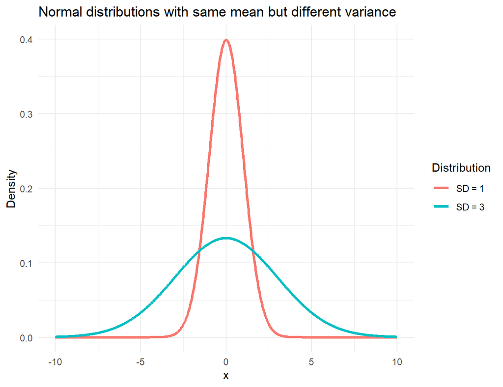

# Range

Simplest measure of variation

Difference between the largest and the smallest observations:
$$Range = X_{largest} − X_{smallest}$$

# Range

Simplest measure of variation

Difference between the largest and the smallest observations:
$$Range = X_{largest} − X_{smallest}$$

### Example

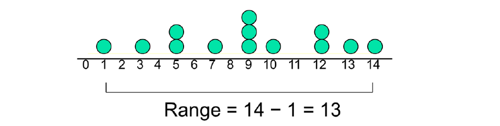

Disadvantages of the range:

- it ignores the way in which data are distributed
- is sensitive to outliers

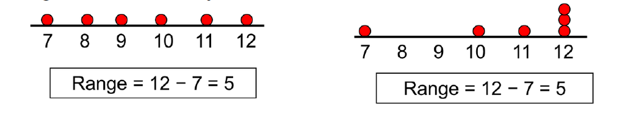

# Interquantile range

Can eliminate some outlier problems by using the interquartile range.

Eliminate high-and low-valued observations and calculate the range of the middle $50\%$ of the data

Defined as the difference between the observation at the $3^{rd}$ quartile and the observation at the $1^{st}$ quartile

$$IQR = Q_3 - Q_1$$

The interquartile range (IQR) measures the spread in the middle $50\%$ of the data

# Variance

### Population variance

Average of squared deviations of values from the mean

$$\sigma^2 = \frac{1}{N} \sum_{i=1}^{N}(x_i - \mu)^2$$

where $\mu$ is the population mean, $N$ is the population size, and $x_i$ is the $i^{th}$ value of variable $x$.

# Variance

### Population variance

Average of squared deviations of values from the mean

$$\sigma^2 = \frac{1}{N} \sum_{i=1}^{N}(x_i - \mu)^2$$
where $\mu$ is the population mean, $N$ is the population size, and $x_i$ is the $i^{th}$ value of variable $x$.

### Sample variance

Average (approximately) of squared deviations of values from the mean

$$s^2 = \frac{1}{n - 1} \sum_{i=1}^{n}(x_i - \bar{x})^2$$

where $\bar{x}$ is the sample mean, $n$ is the sample size, and $x_i$ is the $i^{th}$ value of variable $x$

# Standard deviation

### Population standard deviation

$$\sigma = \sqrt{\frac{1}{N} \sum_{i=1}^{N}(x_i - \mu)^2}$$
where $\mu$ is the population mean, $N$ is the population size, and $x_i$ is the $i^{th}$ value of variable $x$.

# Standard deviation

### Population standard deviation

$$\sigma = \sqrt{\frac{1}{N} \sum_{i=1}^{N}(x_i - \mu)^2}$$
where $\mu$ is the population mean, $N$ is the population size, and $x_i$ is the $i^{th}$ value of variable $x$.

### Sample standard deviation

$$s = \sqrt{\frac{1}{n - 1} \sum_{i=1}^{n}(x_i - \bar{x})^2}$$
where $\bar{x}$ is the sample mean, $n$ is the sample size, and $x_i$ is the $i^{th}$ value of variable $x$.

Standard deviation is the most commonly used measure of variation.

It shows variation around the mean and has the same units as the original data

# Standard deviation

### Population standard deviation

$$\sigma = \sqrt{\frac{1}{N} \sum_{i=1}^{N}(x_i - \mu)^2}$$
where $\mu$ is the population mean, $N$ is the population size, and $x_i$ is the $i^{th}$ value of variable $x$.

### Sample standard deviation

$$s = \sqrt{\frac{1}{n - 1} \sum_{i=1}^{n}(x_i - \bar{x})^2}$$
where $\bar{x}$ is the sample mean, $n$ is the sample size, and $x_i$ is the $i^{th}$ value of variable $x$.

Standard deviation is the most commonly used measure of variation.

It shows variation around the mean and has the same units as the original data

**Advantages of variance and SD**

each value in the data set is used in the calculation

**Disadvantages of variance and SD**

Values far from the mean are given extra weight → because deviations from the mean are squared

# Standard deviation example

sample (10, 12, 14, 15, 17, 18, 18, 24)

We have $n=8$ and mean $\bar{x}=16$, so the standard devation is

$$s=\sqrt{\frac{(10-\bar{x})^2+(12-\bar{x})^2+(14-\bar{x})^2+...+(24-\bar{x})^2)}{n-1}}=
\\
\sqrt{\frac{(10-16)^2+(12-16)^2+(14-16)^2+...+(24-16)^2)}{8-1}}= \\
\sqrt{\frac{130}{7}}=4.3095$$

This is a measure of the “average” scatter around the mean.

# Standard deviation example using R

```r
# Step 1: Define the sample data
sample_data <- c(10, 12, 14, 15, 17, 18, 18, 24)

# Step 2: Calculate the mean
mean_x <- mean(sample_data)

# Step 3: Manually compute the variance
# Formula: variance = sum of squared deviations from the mean divided by (n - 1)
var_manual <- sum((sample_data - mean_x)^2) / (length(sample_data) - 1)

# Step 4: Take the square root of the variance to get the standard deviation
sd_manual <- sqrt(var_manual)

# Step 5: Compare with built-in R functions
var_builtin <- var(sample_data)
sd_builtin <- sd(sample_data)

# Step 6: Output results
list(  Mean = mean_x,  Manual_Variance = var_manual,  Manual_SD = sd_manual,  BuiltIn_Variance = var_builtin,  BuiltIn_SD = sd_builtin)
```

```
## $Mean
## [1] 16
##
## $Manual_Variance
## [1] 18.57143
##
## $Manual_SD
## [1] 4.309458
##
## $BuiltIn_Variance
## [1] 18.57143
##
## $BuiltIn_SD
## [1] 4.309458
```

# Visualisation types

### Boxplot

A box-and-whisker plot is a graph that describes the shape of a distribution in terms of the five-number summary:

1. the minimum value
2. first quartile (25th percentile)
3. the median (a line in the box)
4. the third quartile (75th percentile)
5. and the maximum value.

There are two “whiskers.” One whisker is the line from the 25th percentile to the minimum value; the other whisker is the line from the 75th percentile to the maximum value.

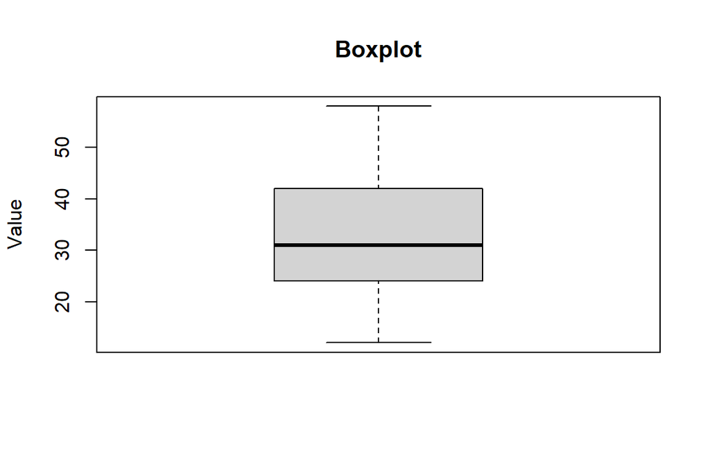

# Visualisation types

### Histogram

A histogram consists of vertical bars constructed on a horizontal line that is marked off with intervals for the variable being displayed.

The intervals correspond to the classes in a frequency distribution table. So, higher bar, higher frequency of this observation in our sample.

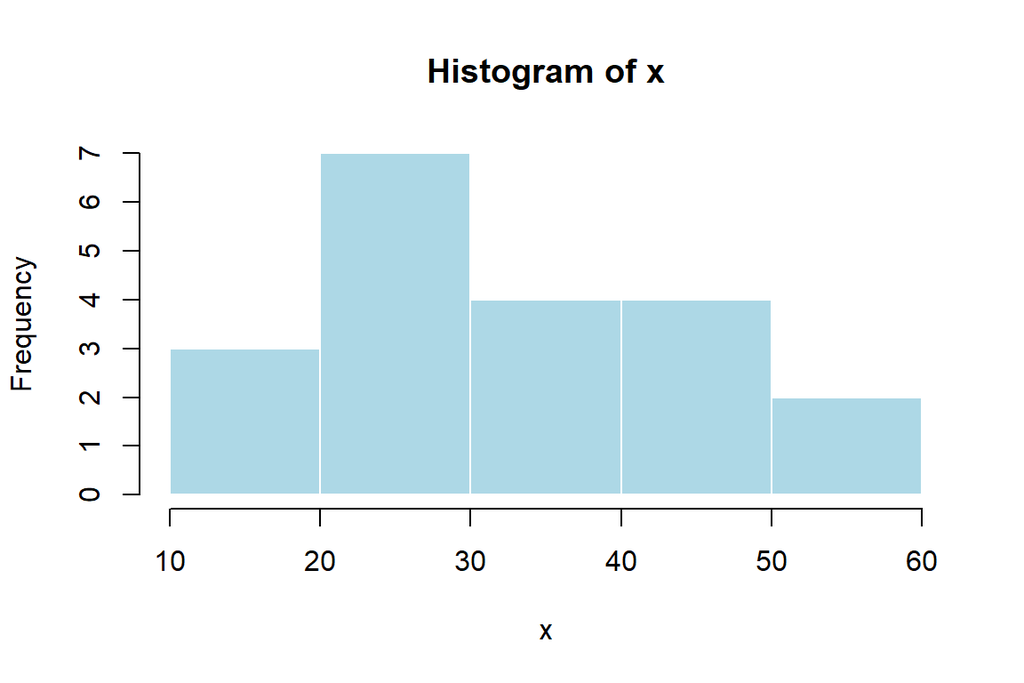